# Analysis of Earnings Per Share(EPS) on Stock Price

by Anthony Kim

Earnings Per Share is one of the readily calculated metrics/ratio that is widely used amongst ranges from retailer investors to professional fund managers. Throughout this data science pipeline, we will discuss, observe, and even try to predict the effects of earnings per share on company's stock prices(if we determine to find linear relationship between percentage change of EPS and stock prices).

There are mainly two things that a public company can do with its net profit. They can either retain them and invest into researching or other areas of making the company more valuable, or they can pay dividends to shareholders(stockholders)

If you are not exposed nor particularly familar with the term "earnings per share", it is simply the net income of the company divided by outstanding common shares outstanding during year. For others who may have more understandings about the different financial ratios, please note that earning per share throughout this data science pipeline refers to the basic earning per share metric and NOT the dilutive earning per share (where causing reduction in the value of shareholding due to the issue of additional shares in a company without an increase in asset is considered).

There is not one and clear answer to what is considered as a good EPS, but we will account for the percentage changes of the EPS and its stock prices throughout years in which the calculation intervals are in respect to annual (10-K) reports of the considered public company.

EPS of the companies that have went through the initial public offering (IPO), are available in the Consolidated Statements of Operations (income statement) in the its annual 10-K report/filing made readily accessible in the Securities and Exchange Commision Website. If you are unfamilar with the term EPS, the most important to note is that EPS intends to measure a company's profitability per share. For example, if you want to invest in some company(meaning you desire to be shareholder of some company), it may serve you well to know how much profit the company has made for per share.

We will take a look at percentage change for this tool/metric, EPS, and perform hypothesis testing, and perhaps seek for opportunity in predicting percentage change for the particular stock in which the EPS pertains to (If there exists significant signs of linear relationship between yearly EPS percentage change and yearly stock price percentage change).

Important note about missing data in stock prices are discussed and taken care of towards the bottom.

Additional insights and information: The Global Industry Classification Standard (aka.GICS) is the primary financial industry standard for defining sector classification. The 11 GICS sector that is commonly used includes:

- Energy
- Materials
- Industrials
- Consumer Discretionary
- Consumer Staples
- Health Care
- Financials
- Information Technology
- Telecommunication Services
- Utilities
- Real Estate

We are going to experiment on 5 popular Tech public company listed, in regards to how its financial health (determined/considered/affected by particular values from the balance sheet, income statement and cash flow statement) stands in regards to the its stock price. In this pipeline, we use EPS to measure how profitable company is per one share.

```python
%store -r fa_key
%pip install yfinance
%pip install FundamentalAnalysis
%pip install pandas_datareader
api_key = fa_key
```

```python
import yfinance as yf
import numpy as np
import matplotlib.pyplot as plt
import pandas as pd
```

```python
import FundamentalAnalysis as fa
import os
```

The tech companies I chose to study are:

- Google (ticker symbol: GOOG)
- Amazon (ticker symbol: AMZN)
- Netflix (ticker symbol: NFLX)
- Intel (ticker symbol: INTC)
- Facebook (ticker symbol: FB)

Note that the defined/chosen/selected 5 companies above are NOT meant to be truly representative of the tech sector of the stock market, but of which pertains to high market cap, and personally interesting stocks/companies to the author.

First thing to do is get the income statement table from FundamentalAnalysis. Then we can seek to get particular information we want from the income statement for particular stocks. (EPS)

# Data and Exploratory Data Analysis

```python
goog_is = fa.income_statement("GOOG", api_key, period="annual")
```

```python
amzn_is = fa.income_statement("AMZN", api_key, period="annual")
```

```python
nflx_is = fa.income_statement("NFLX", api_key, period="annual")
```

```python
intc_is = fa.income_statement("INTC", api_key, period="annual")
```

```python
fb_is = fa.income_statement("FB", api_key, period="annual")
# uncomment below to see the income statement of facebook
# fb_is
```

```python
from typing import List
amzn_is['Ticker'] = "AMZN"
goog_is['Ticker'] = "GOOG"
nflx_is['Ticker'] = "NFLX"
intc_is['Ticker'] = "INTC"
fb_is['Ticker'] = "FB"
```

```python
# Function that takes in sector_list and plots EPS vs. year for every
# company in the given list

def graph_eps_year(sector_list):
    # first set up the fig,ax subplot
    print(type(sector_list))
    fig, ax = plt.subplots(figsize=(15,10))

    # iterate through each of the stocks inside the sector and graph the years on x axis and eps on y axis
    for stock in sector_list:
        stock_yrs = stock.columns[:-1]
        stock_eps = stock.loc['eps']
        # turn into list and sort the years into ascending order.
        # also remember to reverse the values for eps list since we are basically reversing the years
        stock_yrs = list(stock_yrs)
        stock_eps = list(stock_eps[:-1].values)
        stock_yrs.reverse()
        stock_eps.reverse()
        ticker_name = stock.at['eps', 'Ticker']
#         print("we are working on: ", ticker_name)
#         print(stock_yrs)
#         print(stock_eps)
        ax.plot(stock_yrs, stock_eps, label=ticker_name)
    ax.set_title("EPS vs. year")
    ax.set_xlabel("Year")
    ax.set_ylabel("Earnings Per Share (EPS)")
    ax.legend(bbox_to_anchor = (1,1))
```

```python
def graph_eps_year_ind(sector_list):
    # first set up the fig,ax subplot
    # and also get the length of the sector_list
    # since we also want to print out the plot in each subplot
    sector_length = len(sector_list)
    fig2, ax2 = plt.subplots(sector_length, figsize=(15,10))
    # initialize counter here
    counter = 0

    # iterate through each of the stocks inside the sector and graph the years on x axis and eps on y axis
    for stock in sector_list:
        stock_yrs = stock.columns[:-1]
        stock_eps = stock.loc['eps']
        # turn into list and sort the years into ascending order.
        # also remember to reverse the values for eps list since we are basically reversing the years
        stock_yrs = list(stock_yrs)
        stock_eps = list(stock_eps[:-1].values)
        stock_yrs.reverse()
        stock_eps.reverse()
        ticker_name = stock.at['eps', 'Ticker']
#         print("we are working on: ", ticker_name)
#         print(stock_yrs)
#         print(stock_eps)
        ax2[counter].plot(stock_yrs, stock_eps)
        ax2[counter].set_title("EPS vs. year for " + ticker_name)
        ax2[counter].set_xlabel("Year")
        ax2[counter].set_ylabel("Earnings Per Share (EPS)")
        counter += 1
    fig2.tight_layout()
    plt.show()
```

We can make a list for the tech sector (consisted of the 5 particular tech stock companies that we have chosen to study above) and append company's income statement dataframe that we have obtained from API calls. Later we can call the graph_eps_year and graph_eps_year_ind to visualize EPS vs year for the tech sector (with given specific tickers) and each of the company/ticker that are consisted in the tech sector.

```python
tech_sector = []
tech_sector.append(intc_is)
tech_sector.append(amzn_is)
tech_sector.append(goog_is)
tech_sector.append(nflx_is)
tech_sector.append(fb_is)
```

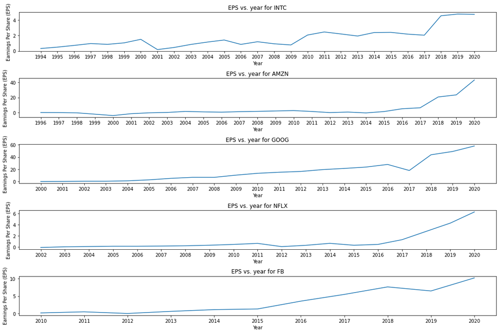

```python
graph_eps_year_ind(tech_sector)
```

Observing the Earnings Per Share vs. Year for each of the different companies in tech_sector, we can see that there seems to be increasing trend of Earnings Per Share. In order to get comparative and more wholistic picture of direction and extent of the increasing of EPS in regards to years.

```
<class 'list'>
```

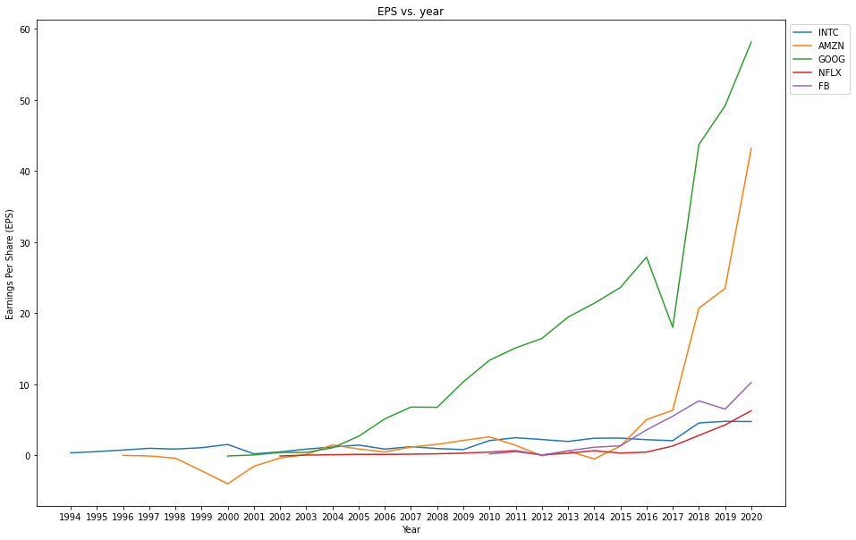

```python
graph_eps_year(tech_sector)
```

Plotting every company's EPS in respect to its years in a same graph, we can observe Google (ticker='GOOG') and Amazon (ticker='AMZN') has a very high upspike in earnings Per share starting from 2017. Earnings per share for companies' Intel (ticker='INTC), Netflix (ticker='NFLX'), and Facebook (ticker='FB') seems to have relatively slight/gentle increase in EPS compared to Amazon and Google which showed significant growth in EPS. In terms of the context, it makes sense to see such high growth for Amazon since they have been growing very quickly over the last 5 years.

Seems to be increasing trend in the EPS for the companies we chose. Since the "raw" value of the particular company's EPS may be little difficult to compare to other company's EPS. We will be looking at the percentage changes. Percentage change may provide us with better opportunity to compare the EPS growth between different companies since we are physically denoting the 'change' of the EPS values of the previous year to current year.

```python
# define function eps percentage change year function.

def graph_epsPCT_year(sector_list: List[str]):
    # first set up the fig,ax subplot
    fig, ax = plt.subplots(figsize=(15,10))

    # iterate through each of the stocks inside the sector and graph the years on x axis and eps on y axis
    for stock in sector_list:
        stock_yrs = stock.columns[:-1]
        stock_eps = stock.loc['eps']
        # turn into list and sort the years into ascending order.
        # also remember to reverse the values for eps list since we are basically reversing the years
        stock_yrs = list(stock_yrs)
        stock_eps = list(stock_eps[:-1].values)
        stock_yrs.reverse()
        stock_eps.reverse()
        # cut out anything that isnt in range 2000-2020
        counter_valid_year = 0
        for year in stock_yrs:
            if (int(year) < 2000):
                counter_valid_year += 1
        stock_yrs = stock_yrs[counter_valid_year:]
        stock_eps = stock_eps[counter_valid_year:]
        # now we should calculate the percentage change. Remeber to input 0 for the very first index
        # since the percentage change is zero for first year compared to itself(first year)
        stock_eps_pct = [((stock_eps[i]-stock_eps[i-1])/stock_eps[i-1]) for i in range(1, len(stock_eps))]
        stock_eps_pct.insert(0,0)
        ticker_name = stock.at['eps', 'Ticker']
#         print("we are working on: ", ticker_name)
#         print(len(stock_yrs))
#         print(len(stock_eps_pct))
#         print(stock_yrs)
#         print(stock_eps)
#         print(stock_eps_pct)
        ax.plot(stock_yrs, stock_eps_pct, label=ticker_name)
    ax.set_title("EPS Percentage change in respect to year")
    ax.set_xlabel("Year")
    ax.set_ylabel("EPS Percentage Change")
    ax.legend(bbox_to_anchor = (1,1))
```

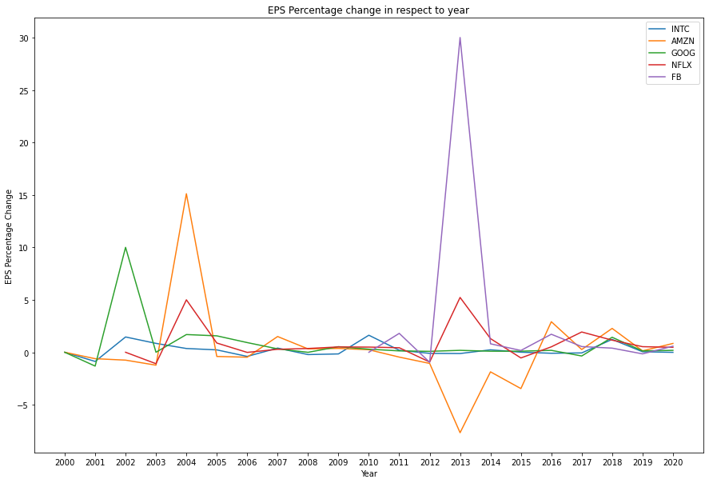

```python
# lets see how graph of EPS percentage change with respect to years looks like
graph_epsPCT_year(tech_sector)
```

From the EPS Percentage Change in respect to year graph above, observe the overlapping upspikes between different companies.

One interesting downspike in EPS Percentage change for Amazon during years 2011 ~ 2013 particularly, makes sense in a contextual manner since Amazon had announced 45 percent year on year decline in profits during 4th quarter of 2012. However, it is important to note that the reason why profits were down was not because the sales were down. That fact will help in understanding how it has picked up its positive uptrend in EPS growth from starting from 2013.

Now lets see some stock prices and furthermore, percentage change.

```python
from pandas_datareader import data as pdr
from datetime import datetime
tech_sector_tickers = ['INTC', 'AMZN', 'GOOG', 'NFLX', 'FB']
```

```python
def graph_D2D_PCT_year(sector_tickers: List[str]):
    # subplot instantiation
    nfigure, naxes = plt.subplots(len(sector_tickers), figsize=(15,10))

    length_tickers = len(sector_tickers)
    counter = 0

    for ticker in sector_tickers:
        data = pdr.get_data_yahoo(ticker, start="2000-01-01", end="2020-01-01", interval='d')
        data.tail()

    # we need to iterate through the data df and put into lists which the dates are 01-01.
    # This will make lot easier to calculate percentage changes from year to year since we
    # have calculated eps percentage yearly.
        years_list = []
        close_price_list = []

        for index, row in data.iterrows():
            year = index.strftime("%y")
            month = index.strftime("%m")
            day = index.strftime("%d")

            years_list.append(index)
            close_price_list.append(data.at[index,'Close'])

        # check if same length
#         print(len(years_list))
#         print(len(close_price_list))
        # calculate percentage change

        price_pct = [((close_price_list[i]-close_price_list[i-1])/close_price_list[i-1]) for i in range(1, len(close_price_list))]
        price_pct.insert(0,0)

        naxes[counter].set_title("Day to Day pct of stock prices of " + ticker)
        naxes[counter].set_xlabel("Year")
        naxes[counter].set_ylabel("price d-d pct")
        naxes[counter].plot(years_list, price_pct, label=ticker)
        counter += 1
    nfigure.tight_layout()
```

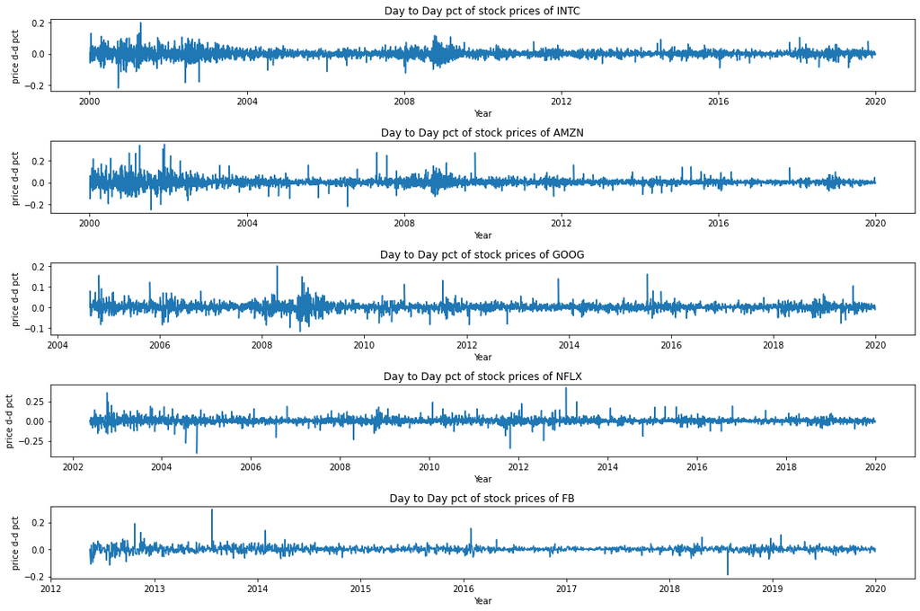

```python
graph_D2D_PCT_year(tech_sector_tickers)
```

Above graph of daily percentage of change of the stock price looks very noisy. Large part of it is because majority of the market is filled with high frequency and algorithmic tradings, so these intraday noises are inevitable. We want the change in yearly basis, not daily.

It makes plausible sense that we calculate percentage changes of the stock with the account to yearly basis since our EPS and EPS percentage change calculation was also through yearly basis. This is due to the fundamental nature of the metric we are using (EPS) since companies gives financial reports quarterly (through document 10-Q) or through annual/yearly (through document 10-K) and because we have decided earlier that we wanted to investigate in terms of year, specifically for the time period of 2000 ~ 2020.

Important information to know before looking at graph_pricePCT_year: The reason why we are getting the stock prices dataframe in the interval of 'm'=month (options were either by day or by month) is because we want to calculate the percentage change of the stock prices in terms of years. This is because for percentage change for stocks from day to day is not meaningful in terms of what we are trying to do. Intraday percentage and for percentage changes of (e.g. today's closing price to yesterday's) stocks will look often strange because there are instituinal traders and algorithms that are performing high frequency trading and often these may look (and often considered) like noise to an investor focused on year-year basis.

```python
# function that plots each of the ticker/company's stock prices during
# the period/intervals of 2000-01-01 ~ 2020-01-01 if available
def graph_pricePCT_year(sector_tickers: List[str]):
    # classic subplot instantiation
    figure, axes = plt.subplots(figsize=(12,10))
    axes.set_title("Yearly Percentage Change of Stock Prices vs. Time")
    axes.set_xlabel("Year")
    axes.set_ylabel("Stock Price Percentage Change")


    for ticker in sector_tickers:
        data = pdr.get_data_yahoo(ticker, start="2000-12-27", end="2020-12-27", interval='m')
        data.tail()

    # we need to iterate through the data df and put into lists which the dates are 01-01.
    # This will make lot easier to calculate percentage changes from year to year since we
    # have calculated eps percentage yearly.
        years_list = []
        close_price_list = []

        for index, row in data.iterrows():
            year = index.strftime("%y")
            month = index.strftime("%m")
            day = index.strftime("%d")
            if (month == '12' and day == '01'):
                years_list.append(index)
                close_price_list.append(data.at[index,'Close'])
#                 print(year)

        # calculate percentage change

        price_pct = [((close_price_list[i]-close_price_list[i-1])/close_price_list[i-1]) for i in range(1, len(close_price_list))]
        price_pct.insert(0,0)

        axes.plot(years_list, price_pct, label=ticker)
    axes.legend(bbox_to_anchor = (1,1))
```

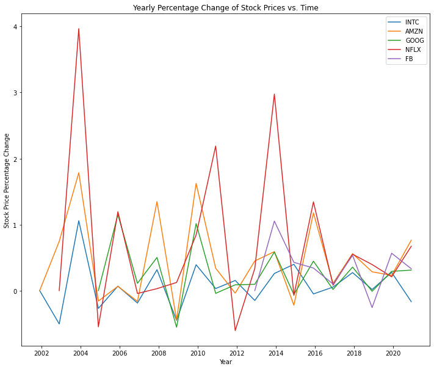

```python
graph_pricePCT_year(tech_sector_tickers)
```

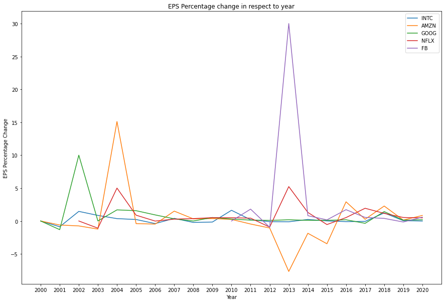

```python
graph_epsPCT_year(tech_sector)
```

It seems that the up-spikes from the graph of yearly stock percentage change and yearly EPS percentage change may have some kind of relationship or a correlation, or possibly maybe even a lagging indicator. For example, observe the high spike both in stock percentage change and in EPS Percentage change for year 2004. Also observe the high spike in 2013, for Facebook and Netflix.

```python
# start making the essential dataframe for both the EPS yearly percentage change and
# yearly stock price changes to go in
def create_essential_df(sector_list):
    data_list_dicts = []
    # iterate through each of the stocks inside the sector and graph the years on x axis and eps on y axis
    for stock in sector_list:

        stock_yrs = stock.columns[:-1]
        stock_eps = stock.loc['eps']
        # turn into list and sort the years into ascending order.
        # also remember to reverse the values for eps list since we are basically reversing the years
        stock_yrs = list(stock_yrs)
        stock_eps = list(stock_eps[:-1].values)
        stock_yrs.reverse()
        stock_eps.reverse()
        # cut out anything that isnt in range 2000-2020
        counter_valid_year = 0
        for year in stock_yrs:
            if (int(year) < 2000):
                counter_valid_year += 1
        stock_yrs = stock_yrs[counter_valid_year:]
        stock_eps = stock_eps[counter_valid_year:]
        # now we should calculate the percentage change. Remeber to input 0 for the very first index
        # since the percentage change is zero for first year compared to itself(first year)
        stock_eps_pct = [((stock_eps[i]-stock_eps[i-1])/stock_eps[i-1]) for i in range(1, len(stock_eps))]
        stock_eps_pct.insert(0,0)
        ticker_name = stock.at['eps', 'Ticker']
#         print("we are working on: ", ticker_name)
#         print(len(stock_yrs))
#         print(len(stock_eps_pct))

        index_counter = 0
        for i in range(0,len(stock_yrs)):
            data_list_dicts.append({'Ticker': ticker_name,
                                    'Year': stock_yrs[index_counter],
                                     'EPS yearly PCT': stock_eps_pct[index_counter]})
            index_counter += 1

    essential_df=pd.DataFrame(data_list_dicts)
    return essential_df
```

```python
essential_df = create_essential_df(tech_sector)
essential_df.head()
```

|  | Ticker | Year | EPS yearly PCT |
| --- | --- | --- | --- |
| 0 | INTC | 2000 | 0.000000 |
| 1 | INTC | 2001 | -0.875552 |
| 2 | INTC | 2002 | 1.457292 |
| 3 | INTC | 2003 | 0.847493 |
| 4 | INTC | 2004 | 0.358443 |

```python
# now create column to insert yearly stock price percentage change
essential_df['StockPrice yearly PCT'] = np.nan
```

```python
# function that returns dictionary of year to EPS yearly PCT.
def get_ticker_to_dict(stock_Ticker):
    data = pdr.get_data_yahoo(stock_Ticker, start="2000-12-01", end="2020-12-01", interval='m')
    data.tail()

    years_list = []
    close_price_list = []

    for index, row in data.iterrows():
        year = index.strftime("%y")
        month = index.strftime("%m")
        day = index.strftime("%d")
        if (month == '12' and day == '01'):
            years_list.append('20'+year)
            close_price_list.append(data.at[index,'Close'])

    # calculate percentage change
    price_pct = [((close_price_list[i]-close_price_list[i-1])/close_price_list[i-1]) for i in range(1, len(close_price_list))]
    price_pct.insert(0,0)
    result = dict(zip(years_list, price_pct))
    return result
```

```python
# make bank (dictionary that contains Ticker to dictionary(Year:Yearly StockPricePCT))
bank = {}
# iterate through list of companies in sector you want and call get_ticker_to_dict
for stock in tech_sector_tickers:
    bank[stock] = get_ticker_to_dict(stock)
```

```python
# go through the entire essential_df dataframe and start inserting values for
# yearly stock price percentage change

for index, row in essential_df.iterrows():
    # first check the ticker and
    # call function get_ticker_to_dict to get the dictionary
    result = bank.get(essential_df.at[index, 'Ticker'])
    yr = essential_df.at[index, 'Year']
    # either insert the value or np.nan that we can check later for
    essential_df.at[index, 'StockPrice yearly PCT'] = result.get(yr, np.nan)
```

# Missing Data

Important information about MISSING DATA: About the possibilities/cases on missing data:

1. Company may have not went public for given time.
2. The nature of the annual calculation of percentage change in stock prices involves choosing specific date that can be compared from year to year basis. *If this date happens to be saturday/sunday, the market is obviously closed. This is a substantial problem since if for example we have stock closing price on year1, and year2, and year3, and year2 closing price is missing because the chosen date may be saturday or sunday (since any date specific date is not guarenteed to be the same day across all years), this will significantly effect the calculation of percentage change. SOLUTION: I have found a way around it by finding the next consecutive day if the date is missing. Using parameter interval ='m' instead of interval='d' when we are fetching stock prices data from yahoo finance allows us to get the closing price of the next weekday consecutive day if the specific date chosen ends up being saturday,sunday. It makes sense since it will prevent the big problem of having no data and affecting the yearly stock price percentage change, and also because blue chips stocks with significant amount of market capitalizations do not usually tend to have price swings that are very signifcant intraday and between say "2 days"

```python
essential_df[essential_df['StockPrice yearly PCT'].isna()]
```

|  | Ticker | Year | EPS yearly PCT | StockPrice yearly PCT |
| --- | --- | --- | --- | --- |
| 42 | GOOG | 2000 | 0.000000 | NaN |
| 43 | GOOG | 2001 | -1.318181 | NaN |
| 44 | GOOG | 2002 | 9.999971 | NaN |
| 45 | GOOG | 2003 | 0.000000 | NaN |
| 82 | FB | 2010 | 0.000000 | NaN |
| 83 | FB | 2011 | 1.800384 | NaN |

```python
essential_df = essential_df.dropna()
```

We have experimented/played around with plots of EPS over time, stock prices over time, yearly percentage change of EPS over time, and yearly percentage change of stock closing price over time. We finally have our dataframe in need (essential_df). So lets plot EPS yearly PCT on the x axis and stock closing price yearly PCT on the y-axis.

# Hypothesis Testing

Before we go further into plotting and hypothesis testing, I am going to define the null hypothesis and alternative hypothesis here:

- Null hypothesis: There is no linear correlationship between EPS yearly PCT and StockPrice yearly PCT.
- Alternative hypothesis: There is linear correlationship between EPS yearly PCT and StockPrice yearly PCT.
- Significance Level (Alpha): $\alpha$ = 0.05

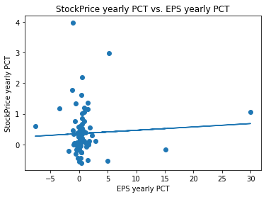

```python
# scattor plot EPS yearly PCT on x-axis and StockPrice yearly PCT on y-axis
fig5, ax5 = plt.subplots()
essential_df['EPS yearly PCT']
ax5.scatter(essential_df['EPS yearly PCT'], essential_df['StockPrice yearly PCT'])

# we can also try fitting the linear regression model
# this will help in spotting linear relationship
from sklearn.linear_model import LinearRegression
ind = [[i] for i in essential_df['EPS yearly PCT'].values]
dep = [[j] for j in essential_df['StockPrice yearly PCT'].values]
reg = LinearRegression().fit(ind, dep)
ax5.plot(essential_df['EPS yearly PCT'], reg.predict(ind))
ax5.set_title("StockPrice yearly PCT vs. EPS yearly PCT")
ax5.set_xlabel("EPS yearly PCT")
ax5.set_ylabel("StockPrice yearly PCT")
```

```python
import scipy.stats
scipy.stats.pearsonr(essential_df['EPS yearly PCT'], essential_df['StockPrice yearly PCT'])
```

```
(0.05844764220531987, 0.5907577519369059)
```

As you can see in the scatter plot of StockPrice yearly PCT vs. EPS yearly PCT, there isn't seem to be linear correlation between the StockPrice yearly PCT and EPS yearly PCT. Also observing the pearson's correlation coefficient (of 0.05844764220531987) and the p-value (0.5907577519369059), we fail to reject the null hypothesis of there is no linear relationship between EPS yearly PCT and StockPrice yearly PCT. Also note that the pearson's correlation coefficient seems very low/unlikely implying absence of linear relationship between the two datasets of essential_df['EPS yearly PCT'] and essential_df['StockPrice yearly PCT']

However, there is still possibility of linear relationship between StockPrice yearly PCT and EPS yearly PCT, which can be visualized/explored through plotting this graph of StockPrice yearly PCT and EPS yearly PCT SEPARATELY for each stock(ticker).

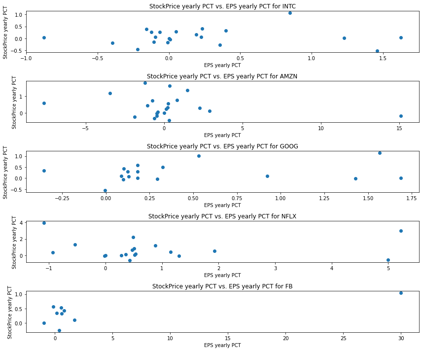

```python
# Plot individually.
# need iterate and plot for each ticker in essential_df
tickers_list = essential_df['Ticker'].unique()
num_plt = len(tickers_list)
fig_indi, ax_indi = plt.subplots(num_plt, figsize=(12,10))
counter = 0

for ticker in tickers_list:
    temp = essential_df[essential_df['Ticker'] == ticker]
    ax_indi[counter].scatter(temp['EPS yearly PCT'], temp['StockPrice yearly PCT'])
    ax_indi[counter].set_title("StockPrice yearly PCT vs. EPS yearly PCT for " + ticker)
    ax_indi[counter].set_xlabel("EPS yearly PCT")
    ax_indi[counter].set_ylabel("StockPrice yearly PCT")
    counter += 1

fig_indi.tight_layout()
plt.show()
```

On the plots below, we fit the linear regression model specific to each of the ticker/stock in order to see if there are any apparent linear relationship specific to particular company.

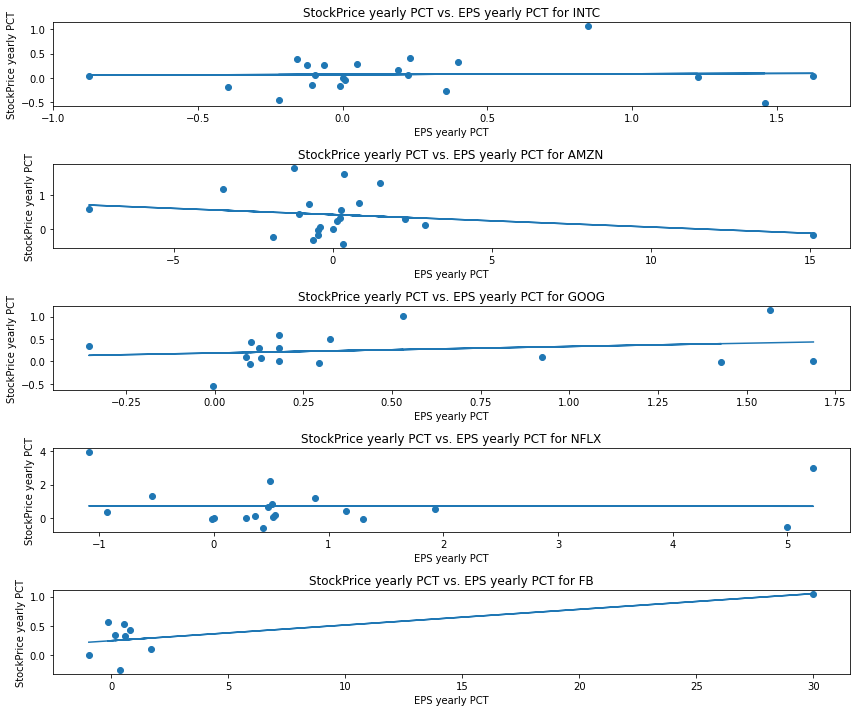

```python
# Plot individually.
# need iterate and plot for each ticker in essential_df
tickers_list = essential_df['Ticker'].unique()
num_plt = len(tickers_list)
fig_indi2, ax_indi2 = plt.subplots(num_plt, figsize=(12,10))
counter = 0

for ticker in tickers_list:
    temp = essential_df[essential_df['Ticker'] == ticker]
    ax_indi2[counter].scatter(temp['EPS yearly PCT'], temp['StockPrice yearly PCT'])
    # we can try fitting linear regression line for each of the chosen ticker
    ind2 = [[i] for i in temp['EPS yearly PCT'].values]
    dep2 = [[j] for j in temp['StockPrice yearly PCT'].values]
    reg2 = LinearRegression().fit(ind2, dep2)
    ax_indi2[counter].plot(temp['EPS yearly PCT'], reg2.predict(ind2))
    ax_indi2[counter].set_title("StockPrice yearly PCT vs. EPS yearly PCT for " + ticker)
    ax_indi2[counter].set_xlabel("EPS yearly PCT")
    ax_indi2[counter].set_ylabel("StockPrice yearly PCT")
    counter += 1

fig_indi2.tight_layout()
plt.show()
```

The scatterplots for each of the ticker with linear regression lines looks less horrible than the combined scatterplots with linear regression from before, but it is still very hard to see a clear linear correlationship between EPS yearly PCT and stockprice yearly PCT. Linear regression line seems to fit in less awkwardly compared to the group scatterplot linear regression, but still not convincing at all.

# Conclusion

Throughout this data science pipepline, I have walked through exploring and analyzing the potential linear relationship between Earnings Per Share on specifically chosen tech stock and its stock prices. Exploratory analysis and the hypothesis testing may have not provided results that will satisfy investors (or I should say speculators believing there is a magical simple indicator) who are willing to throw money into the stock market, thinking one ratio will be "sufficient" or "good enough".

The truth is, there are many other factors, not only other fundamental analysis metrics and ratios, but also advanced mathematical models and high frequency algorithmic trading and speculation that is dominating the market today. I hope that this data science pipeline clearly showed you that one indepedent variable is not sufficient enough nor a guarentee to predict the stock prices today.

# Additional Resources

If you find above topic interesting here are some additional resources to learn more about:

- https://www.investopedia.com/terms/r/relative-valuation-model.asp
- https://www.investopedia.com/terms/p/price-earningsratio.asp (P/E ratio uses EPS in its calculation)
- https://www.fidelity.com/learning-center/trading-investing/fundamental-analysis/analyzing-stock-fundamentals-learning-path
- https://www.marketwatch.com/story/high-frequency-trading-brings-real-benefits-but-still-could-wind-up-hurting-the-stock-market-heres-why-11622729169 (Article on high frequency trading)
- https://www.wallstreetmojo.com/fundamental-analysis-vs-technical-analysis/ (fundamental analysis vs. technical analysis)